# 水3 調査実習 第3回 2変数の関係: 散布図と相関

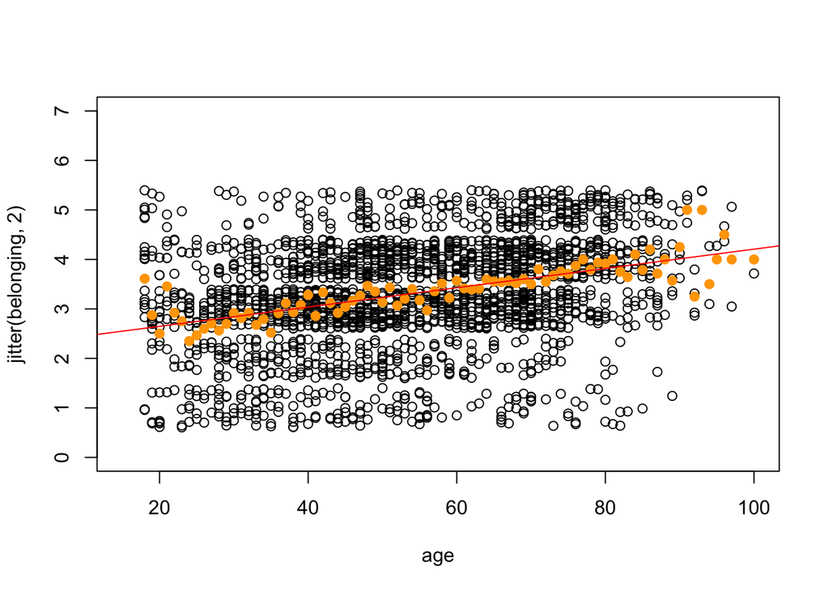

```
## integer(0)
```

```r
plot(jitter(belonging, 2) ~ age, data = kwsk, xlim = c(15, 100), ylim = c(0, 7)) +
kwsk %>% filter(!is.na(age), !is.na(belonging)) %>%
  group_by(age) %>%
  summarize(belonging.mean = mean(belonging)) %>%
  points(., col = "orange", pch = 19, cex = 1) +
abline(lm(belonging ~ age, data = kwsk), col = "red")
```

```r
library(GGally)
kwsk.complete <- kwsk %>% select(belonging, age, female, income, edu.int, happiness, health, residency, relationship) %>%
  na.omit
```

```r
ols1 <- lm(belonging ~ age, data = kwsk.complete)
summary(ols1)
```

```
##
## Call:
## lm(formula = belonging ~ age, data = kwsk.complete)
##
## Residuals:
##      Min       1Q   Median       3Q      Max
## -2.90496 -0.55519  0.00832  0.71685  2.39695
##
## Coefficients:
##             Estimate Std. Error t value Pr(>|t|)
## (Intercept) 2.253280   0.085993   26.20   <2e-16 ***
## age         0.019431   0.001588   12.24   <2e-16 ***
## ---
## Signif. codes:  0 '***' 0.001 '**' 0.01 '*' 0.05 '.' 0.1 ' ' 1
##
## Residual standard error: 0.9677 on 1445 degrees of freedom
## Multiple R-squared:  0.0939, Adjusted R-squared:  0.09327
## F-statistic: 149.7 on 1 and 1445 DF,  p-value: < 2.2e-16
```

```r
ols2 <- lm(belonging ~ age + female + log(income + 1) + edu.int, data = kwsk.complete)
summary(ols2)
```

```
##
## Call:
## lm(formula = belonging ~ age + female + log(income + 1) + edu.int,
##     data = kwsk.complete)
##
## Residuals:
##      Min       1Q   Median       3Q      Max
## -2.86528 -0.55706  0.02521  0.68839  2.52598
##
## Coefficients:
##                 Estimate Std. Error t value Pr(>|t|)
## (Intercept)     1.297247   0.279331   4.644 3.73e-06 ***
## age             0.021315   0.001682  12.670  < 2e-16 ***
## female          0.221281   0.051360   4.308 1.76e-05 ***
## log(income + 1) 0.072283   0.027010   2.676  0.00753 **
## edu.int         0.019655   0.013831   1.421  0.15551
## ---
## Signif. codes:  0 '***' 0.001 '**' 0.01 '*' 0.05 '.' 0.1 ' ' 1
##
## Residual standard error: 0.9593 on 1442 degrees of freedom
## Multiple R-squared:  0.1114, Adjusted R-squared:  0.1089
## F-statistic: 45.18 on 4 and 1442 DF,  p-value: < 2.2e-16
```

```r
ols3 <- lm(belonging ~ age + female + log(income + 1) + edu.int +
             happiness + health, data = kwsk.complete)
summary(ols3)
```

```
##
## Call:
## lm(formula = belonging ~ age + female + log(income + 1) + edu.int +
##     happiness + health, data = kwsk.complete)
##
## Residuals:
##      Min       1Q   Median       3Q      Max
## -2.96376 -0.53964  0.04009  0.64924  2.61350
##
## Coefficients:
##                   Estimate Std. Error t value Pr(>|t|)
## (Intercept)      0.3891219  0.3073052   1.266  0.20563
## age              0.0199969  0.0016882  11.845  < 2e-16 ***
## female           0.1502437  0.0505139   2.974  0.00299 **
## log(income + 1) -0.0005684  0.0271995  -0.021  0.98333
## edu.int          0.0056446  0.0134762   0.419  0.67538
## happiness        0.4141857  0.0433316   9.559  < 2e-16 ***
## health           0.0594972  0.0348485   1.707  0.08798 .
## ---
## Signif. codes:  0 '***' 0.001 '**' 0.01 '*' 0.05 '.' 0.1 ' ' 1
##
## Residual standard error: 0.9287 on 1440 degrees of freedom
## Multiple R-squared:  0.1684, Adjusted R-squared:  0.1649
## F-statistic:  48.6 on 6 and 1440 DF,  p-value: < 2.2e-16
```

```r
ols4 <- lm(belonging ~ age + female + log(income + 1) + edu.int +
             happiness + health + residency + relationship, data = kwsk.complete)
summary(ols4)
```

```
##
## Call:
## lm(formula = belonging ~ age + female + log(income + 1) + edu.int +
##     happiness + health + residency + relationship, data = kwsk.complete)
##
## Residuals:
##     Min      1Q  Median      3Q     Max
## -2.7314 -0.5245  0.0585  0.5927  2.5259
##
## Coefficients:
##                  Estimate Std. Error t value Pr(>|t|)
## (Intercept)      0.368056   0.293661   1.253    0.210
## age              0.010100   0.001965   5.139 3.15e-07 ***
## female           0.017806   0.049057   0.363    0.717
## log(income + 1) -0.014892   0.025926  -0.574    0.566
## edu.int          0.008624   0.012790   0.674    0.500
## happiness        0.295194   0.042181   6.998 3.96e-12 ***
## health           0.039695   0.033106   1.199    0.231
## residency        0.006543   0.002114   3.096    0.002 **
## relationship     0.427576   0.036422  11.739  < 2e-16 ***
## ---
## Signif. codes:  0 '***' 0.001 '**' 0.01 '*' 0.05 '.' 0.1 ' ' 1
##
## Residual standard error: 0.8812 on 1438 degrees of freedom
## Multiple R-squared:  0.2522, Adjusted R-squared:  0.2481
## F-statistic: 60.63 on 8 and 1438 DF,  p-value: < 2.2e-16
```

```r
stargazer(ols3, ols4, type="latex",
          title="回帰結果", single.row=TRUE,
          ci=FALSE, ci.level=0.95, omit.stat=c("f", "ser"))
```

```
##
## % Table created by stargazer v.5.2.2 by Marek Hlavac, Harvard University. E-mail: hlavac at fas.harvard.edu
## % Date and time: Mon, Apr 05, 2021 - 17:18:29
## \begin{table}[!htbp] \centering
##   \caption{回帰結果}
##   \label{}
## \begin{tabular}{@{\extracolsep{5pt}}lcc}
## \\[-1.8ex]\hline
## \hline \\[-1.8ex]
##  & \multicolumn{2}{c}{\textit{Dependent variable:}} \\
## \cline{2-3}
## \\[-1.8ex] & \multicolumn{2}{c}{belonging} \\
## \\[-1.8ex] & (1) & (2)\\
## \hline \\[-1.8ex]
##  age & 0.020$^{***}$ (0.002) & 0.010$^{***}$ (0.002) \\
##   female & 0.150$^{***}$ (0.051) & 0.018 (0.049) \\
##   log(income + 1) & $-$0.001 (0.027) & $-$0.015 (0.026) \\
##   edu.int & 0.006 (0.013) & 0.009 (0.013) \\
##   happiness & 0.414$^{***}$ (0.043) & 0.295$^{***}$ (0.042) \\
##   health & 0.059$^{*}$ (0.035) & 0.040 (0.033) \\
##   residency &  & 0.007$^{***}$ (0.002) \\
##   relationship &  & 0.428$^{***}$ (0.036) \\
##   Constant & 0.389 (0.307) & 0.368 (0.294) \\
##  \hline \\[-1.8ex]
## Observations & 1,447 & 1,447 \\
## R$^{2}$ & 0.168 & 0.252 \\
## Adjusted R$^{2}$ & 0.165 & 0.248 \\
## \hline
## \hline \\[-1.8ex]
## \textit{Note:}  & \multicolumn{2}{r}{$^{*}$p$<$0.1; $^{**}$p$<$0.05; $^{***}$p$<$0.01} \\
## \end{tabular}
## \end{table}
```

## 課題

1. データから自分が興味を持つ変数を2つから5つほど選び（それより多くなっても構わない）、適切な前処理（欠損値の処理、リコード、カテゴリー化など）をする。その変数の特性（すなわち、その変数が何をどのように測定したものであるか、カテゴリカルか量的か、順序尺度か比率尺度かなど）について、各変数ごとに短い説明を付ける。
   1. 記述統計（平均、分散、最大値、最小値）をつける。
2. その変数の間に相関が存在するか、存在するならばそれはどのような関係によるものかを想像し、簡単な理論仮説・作業仮説を作る。
3. 選択した変数の散布図を作り、共分散・ピアソン相関係数（またはKendall’s tau や Spearman’s rho）を求め、求めたグラフ・相関係数の解釈を短く述べること。相関係数には検定結果（p-value）をつける。散布図に回帰直線や、なんらかの近似線を描いても良い。
   1. 必要だと判断した場合は散布図ではなく別のタイプのグラフを描いたり、相関を示すための別の指標を用いたりしても構わない。ただし、その場合は適切な説明を付け加える。
4. 3で得られた結果と2で想像して立てた仮説の関係を短く考察する。求めた相関係数は実際のデータに見られる関係を適切に表しているか。それらの変数の間には本当に相関があったと言えるか。第3要因や偶然による疑似相関ではないか。もしそうならば、考慮に入れるべき（統制すべき）第3要因としては何があり得るか。

締め切り：5月31日23時59分

提出場所：ITC-LMS

形式上の注意：

1. 名前と学籍番号をつける。
2. すべての表・図には適切なタイトルをつける。
3. .doc, .docx, または .pdf 形式で提出する。
4. 自分が用いたコードを添付すること。